# Alpha diversity — filtered cohort

Anton

2026-05-31

```r
knitr::opts_knit$set(root.dir = rprojroot::find_rstudio_root_file())
knitr::opts_chunk$set(echo = TRUE, message = FALSE, warning = FALSE)
```

# Purpose

Alpha diversity within the filtered Chinese cohort (`Project.ID == "PRJNA422434"`, 187 T2D + 172 Healthy). All analyses run at both genus and species level. The headline test is Wilcoxon rank-sum; group medians, depth confounding, and covariate adjustment are also reported.

# 1. Libraries

```r
library(phyloseq)
library(vegan)
library(ggplot2)
library(dplyr)
library(tibble)
library(tidyr)
```

> *Taught in: W20-02 (`02_statistical_testing_of_alpha_diversity.Rmd`) §1 — phyloseq + tidyverse for alpha-diversity testing; ggplot2 from the W20 diversity practicals.*

# 2. Load and filter data

Load the original phyloseq objects and restrict to the Chinese cohort (`Project.ID == "PRJNA422434"`). The rationale for this filter is documented separately; in short, the other two projects in the dataset are case-only and cannot contribute to a case-control comparison.

```r
# Genus level
load("project/data/D003924_Diabetes_Mellitus,_T/genus/phyloseq.RData")
ps_genus_clean <- subset_samples(pylsq, Project.ID == "PRJNA422434")
rm(pylsq)

# Species level
load("project/data/D003924_Diabetes_Mellitus,_T/species/phyloseq.RData")
ps_species_clean <- subset_samples(pylsq, Project.ID == "PRJNA422434")
rm(pylsq)

ps_genus_clean
```

```
## phyloseq-class experiment-level object
## otu_table()   OTU Table:         [ 58 taxa and 359 samples ]
## sample_data() Sample Data:       [ 359 samples by 12 sample variables ]
## tax_table()   Taxonomy Table:    [ 58 taxa by 7 taxonomic ranks ]
## phy_tree()    Phylogenetic Tree: [ 58 tips and 27 internal nodes ]
```

```r
ps_species_clean
```

```
## phyloseq-class experiment-level object
## otu_table()   OTU Table:         [ 173 taxa and 359 samples ]
## sample_data() Sample Data:       [ 359 samples by 12 sample variables ]
## tax_table()   Taxonomy Table:    [ 173 taxa by 7 taxonomic ranks ]
## phy_tree()    Phylogenetic Tree: [ 173 tips and 59 internal nodes ]
```

> *Taught in: W20-01/W20-02 — loading the course phyloseq objects; `subset_samples()` is the phyloseq subsetting shown in W20-03 (`03_beta_diversity_and_ordination.Rmd`). Cohort filter (PRJNA422434 only) is project-chosen, rationale in `cohort_rationale.Rmd`.*

# 3. Build a tidy alpha-diversity table at both levels

```r
make_alpha_df <- function(ps, level_label) {
  alpha <- estimate_richness(ps, measures = c("Shannon", "Simpson", "InvSimpson")) |>
    rownames_to_column("sample_id")

  meta <- sample_data(ps) |>
    data.frame() |>
    rownames_to_column("sample_id")

  inner_join(alpha, meta, by = "sample_id") |>
    mutate(level = level_label)
}

alpha_genus   <- make_alpha_df(ps_genus_clean,   "Genus")
alpha_species <- make_alpha_df(ps_species_clean, "Species")
alpha_all     <- bind_rows(alpha_genus, alpha_species)

head(alpha_all)
```

```
##    sample_id   Shannon   Simpson InvSimpson     Run.ID  Project.ID
## 1 SRR1778450 0.4014666 0.1726723   1.208711 SRR1778450 PRJNA422434
## 2 SRR1778451 1.4646920 0.6689347   3.020552 SRR1778451 PRJNA422434
## 3 SRR1778452 1.8582086 0.7997067   4.992678 SRR1778452 PRJNA422434
## 4 SRR1778453 1.7237338 0.7675498   4.301997 SRR1778453 PRJNA422434
## 5 SRR1778454 1.4293783 0.6125890   2.581238 SRR1778454 PRJNA422434
## 6 SRR1778455 1.2947603 0.6568455   2.914139 SRR1778455 PRJNA422434
##   Experiment.type Nr..reads.sequenced Country    Sex Host.age   BMI
## 1    metagenomics            23038170   China   Male       37    NA
## 2    metagenomics            29266886   China   Male       78 20.58
## 3    metagenomics            32758437   China Female       65 20.78
## 4    metagenomics            28064538   China Female       65 25.30
## 5    metagenomics            39958225   China   Male       63 22.84
## 6    metagenomics            49892410   China   Male       65 21.01
##   Recent.antibiotics.use Disease.MESH.ID Disease.name QC.status level
## 1                      N         D003924            1         1 Genus
## 2                      N         D003924            1         1 Genus
## 3                      N         D003924            1         1 Genus
## 4                      N         D003924            1         1 Genus
## 5                      N         D003924            1         1 Genus
## 6                      N         D003924            1         1 Genus
```

> *Taught in: W20-02 §2 — `estimate_richness()` for Shannon/Simpson/InvSimpson. Joining the richness table to `sample_data()` follows the same practical.*

`Shannon`/`Simpson`/`InvSimpson` work directly on the relative-abundance table. `Observed`/`Chao1`/`ACE`, however, assume integer counts and error on continuous relative abundances. W20-02 shows the correct route for non-count data: convert to **presence/absence** first, then count detected taxa. We add Observed that way so the metric is available without misusing the abundance values.

```r
make_observed_df <- function(ps, level_label) {
  ps_pa <- transform_sample_counts(ps, function(x) ifelse(x > 0, 1, 0))
  estimate_richness(ps_pa, measures = "Observed") |>
    rownames_to_column("sample_id") |>
    mutate(level = level_label)
}

observed_all <- bind_rows(
  make_observed_df(ps_genus_clean,   "Genus"),
  make_observed_df(ps_species_clean, "Species")
)

# Attach Observed to the main table by sample_id + level
alpha_all <- alpha_all |>
  left_join(observed_all, by = c("sample_id", "level"))

head(observed_all)
```

```
##    sample_id Observed level
## 1 SRR1778450        9 Genus
## 2 SRR1778451        9 Genus
## 3 SRR1778452        9 Genus
## 4 SRR1778453        9 Genus
## 5 SRR1778454        9 Genus
## 6 SRR1778455        9 Genus
```

> *Taught in: W20-02 §2 — the practical builds `ps_pa <- transform_sample_counts(ps, function(x) ifelse(x > 0, 1, 0))` and runs `estimate_richness(ps_pa, measures = "Observed")`. Observed on presence/absence = the number of detected taxa per sample, which is well defined even though the raw table is relative abundance.*

Observed is interpreted with care here: the taxon panel is fixed (a closed MetaPhlAn reference), so Observed reflects **how many of the reference taxa each sample carries**, not open-ended richness. A group difference in Observed is still meaningful (it says one group’s communities are detectably broader), but it is bounded by the panel size.

# 4. Wilcoxon tests per metric and level

```r
metrics_to_test <- c("Observed", "Shannon", "Simpson", "InvSimpson")
levels_to_test  <- c("Genus", "Species")

wilcox_results <- tibble()

for (lvl in levels_to_test) {
  sub <- alpha_all |> filter(level == lvl)
  for (m in metrics_to_test) {
    w <- wilcox.test(reformulate("Disease.MESH.ID", m), data = sub)
    wilcox_results <- bind_rows(
      wilcox_results,
      tibble(
        level     = lvl,
        metric    = m,
        W         = unname(w$statistic),
        p_value   = w$p.value,
        median_T2D = median(sub[[m]][sub$Disease.MESH.ID == "D003924"]),
        median_HC  = median(sub[[m]][sub$Disease.MESH.ID == "D006262"])
      )
    )
  }
}

wilcox_results <- wilcox_results |>
  mutate(p_value = signif(p_value, 3))

wilcox_results
```

```
## # A tibble: 8 × 6
##   level   metric         W   p_value median_T2D median_HC
##   <chr>   <chr>      <dbl>     <dbl>      <dbl>     <dbl>
## 1 Genus   Observed   16082 NaN            9         9
## 2 Genus   Shannon    19144   0.00183      1.60      1.54
## 3 Genus   Simpson    19103   0.00211      0.715     0.686
## 4 Genus   InvSimpson 19103   0.00211      3.51      3.19
## 5 Species Observed   15824   0.0964       9         9
## 6 Species Shannon    17271   0.226        1.92      1.91
## 7 Species Simpson    17129   0.287        0.818     0.810
## 8 Species InvSimpson 17129   0.287        5.51      5.26
```

> *Taught in: W20-02 — Wilcoxon rank-sum (`wilcox.test`) / Kruskal-Wallis for two-group alpha-diversity comparison; group medians are the descriptive summary shown alongside the test in the same practical.*

# 5. Group medians and spread (IQR)

The Wilcoxon test above is non-parametric, so the matching descriptive summary is the group median and interquartile range (IQR) rather than a parametric effect size. This describes the size and direction of the difference using the same rank-based logic as the test.

```r
median_iqr <- tibble()

for (lvl in levels_to_test) {
  sub <- alpha_all |> filter(level == lvl)
  for (m in metrics_to_test) {
    t2d <- sub[[m]][sub$Disease.MESH.ID == "D003924"]
    hc  <- sub[[m]][sub$Disease.MESH.ID == "D006262"]
    median_iqr <- bind_rows(
      median_iqr,
      tibble(
        level      = lvl,
        metric     = m,
        median_T2D = median(t2d),
        IQR_T2D    = IQR(t2d),
        median_HC  = median(hc),
        IQR_HC     = IQR(hc),
        median_diff = median(t2d) - median(hc)
      )
    )
  }
}

median_iqr <- median_iqr |>
  mutate(across(where(is.numeric), \(x) round(x, 3)))

median_iqr
```

```
## # A tibble: 8 × 7
##   level   metric     median_T2D IQR_T2D median_HC IQR_HC median_diff
##   <chr>   <chr>           <dbl>   <dbl>     <dbl>  <dbl>       <dbl>
## 1 Genus   Observed        9       0         9      0           0
## 2 Genus   Shannon         1.60    0.417     1.54   0.454       0.061
## 3 Genus   Simpson         0.715   0.155     0.686  0.212       0.029
## 4 Genus   InvSimpson      3.51    2.18      3.19   1.90        0.319
## 5 Species Observed        9       0         9      0           0
## 6 Species Shannon         1.92    0.274     1.91   0.377       0.016
## 7 Species Simpson         0.818   0.085     0.81   0.118       0.009
## 8 Species InvSimpson      5.51    2.37      5.26   2.89        0.248
```

> *Taught in: W20-02 — median/IQR are the standard descriptive summary paired with the Wilcoxon test in the alpha-diversity practical. (Rank-biserial effect size from the `effectsize` package was removed: not part of the course material.)*

# 6. Depth confounding

A diversity difference could in principle reflect differential sequencing depth between groups. Spearman correlation between depth (`Nr..reads.sequenced`) and Shannon diversity tests this directly.

```r
depth_results <- alpha_all |>
  group_by(level) |>
  summarise(
    rho      = cor(Nr..reads.sequenced, Shannon, method = "spearman"),
    p_value  = cor.test(Nr..reads.sequenced, Shannon, method = "spearman")$p.value
  ) |>
  mutate(across(c(rho, p_value), \(x) signif(x, 3)))

depth_results
```

```
## # A tibble: 2 × 3
##   level       rho p_value
##   <chr>     <dbl>   <dbl>
## 1 Genus    0.0582   0.271
## 2 Species -0.0369   0.486
```

> *Taught in: W20-02 — sequencing-depth confounding exercise: Spearman `cor.test(..., method = "spearman")` of depth against a diversity metric. (Here depth = `Nr..reads.sequenced` from sample metadata.)*

A small |ρ| (< 0.1) and a non-significant p-value indicate no meaningful depth confound.

# 7. Visualise alpha diversity by disease

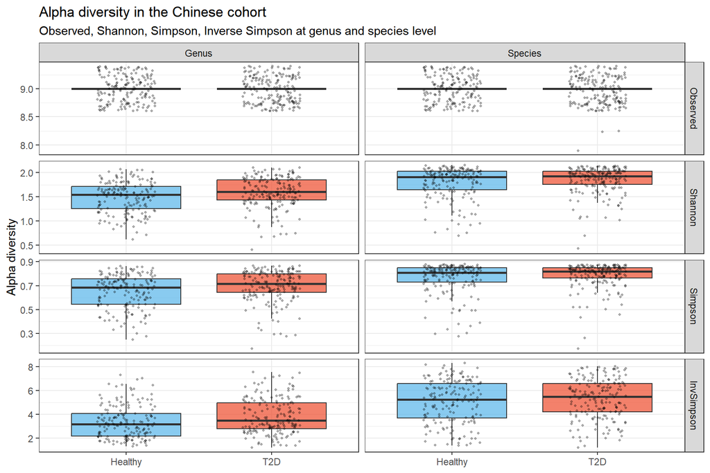

```r
alpha_long <- alpha_all |>
  select(sample_id, level, Disease.MESH.ID,
         Observed, Shannon, Simpson, InvSimpson) |>
  pivot_longer(cols = c(Observed, Shannon, Simpson, InvSimpson),
               names_to = "metric", values_to = "value") |>
  mutate(
    Disease = ifelse(Disease.MESH.ID == "D003924", "T2D", "Healthy"),
    metric  = factor(metric, levels = c("Observed", "Shannon", "Simpson", "InvSimpson"))
  )

ggplot(alpha_long, aes(x = Disease, y = value, fill = Disease)) +
  geom_boxplot(alpha = 0.7, outlier.shape = NA) +
  geom_jitter(width = 0.2, alpha = 0.3, size = 0.8) +
  facet_grid(metric ~ level, scales = "free_y") +
  scale_fill_manual(values = c("Healthy" = "#56B4E9", "T2D" = "#EE4B2B")) +
  theme_bw() +
  theme(legend.position = "none") +
  labs(x = NULL, y = "Alpha diversity",
       title = "Alpha diversity in the Chinese cohort",
       subtitle = "Observed, Shannon, Simpson, Inverse Simpson at genus and species level")
```

> *Taught in: W20-02 — boxplots of alpha diversity by group (`plot_richness` / ggplot boxplots) in the alpha-diversity practical.*

# 8. Covariate adjustment

Within the filtered cohort, additional covariates may still confound the disease effect — BMI, host age, and sex are biologically plausible candidates. Wilcoxon does not natively adjust for covariates, so we switch to a linear model on Shannon diversity. This is reasonable because Shannon at sample level is approximately continuous and not extremely skewed.

```r
# Inspect covariate availability
summary(alpha_genus$BMI)
```

```
##    Min. 1st Qu.  Median    Mean 3rd Qu.    Max.    NA's
##   16.00   19.47   20.90   22.57   25.62   32.58     208
```

```r
summary(alpha_genus$Host.age)
```

```
##    Min. 1st Qu.  Median    Mean 3rd Qu.    Max.
##   13.00   40.00   49.00   48.59   58.00   86.00
```

```r
table(alpha_genus$Sex, alpha_genus$Disease.MESH.ID, useNA = "ifany")
```

```
##
##          D003924 D006262
##   Female      68      81
##   Male       119      91
```

> *Taught in: W21 reference Rmd §7 / Alberdi reading (“Multivariate statistics and multiple correction”) §5 — covariate inspection prior to adjustment. BMI / host age / sex are project-chosen covariates (the method of adjusting for covariates is taught; the specific choice of these three is ours).*

If `BMI` has many NAs, those samples are dropped from the adjusted model only — the unadjusted comparison still uses all samples.

```r
alpha_genus_complete <- alpha_genus |>
  filter(!is.na(BMI), !is.na(Host.age), !is.na(Sex))

mod_unadjusted <- lm(Shannon ~ Disease.MESH.ID,
                     data = alpha_genus_complete)

mod_adjusted   <- lm(Shannon ~ Disease.MESH.ID + BMI + Host.age + Sex,
                     data = alpha_genus_complete)

summary(mod_unadjusted)$coefficients
```

```
##                          Estimate Std. Error   t value     Pr(>|t|)
## (Intercept)             1.5478315 0.03658726 42.305202 6.517461e-85
## Disease.MESH.IDD006262 -0.0691028 0.05226399 -1.322188 1.881317e-01
```

```r
summary(mod_adjusted)$coefficients
```

```
##                            Estimate  Std. Error    t value     Pr(>|t|)
## (Intercept)             1.862212257 0.192374179  9.6801570 1.994297e-17
## Disease.MESH.IDD006262 -0.089335523 0.068324774 -1.3075129 1.930938e-01
## BMI                    -0.010203403 0.007777624 -1.3118920 1.916156e-01
## Host.age               -0.001075549 0.002330694 -0.4614715 6.451471e-01
## SexMale                -0.042564121 0.055546937 -0.7662731 4.447510e-01
```

> *Taught in: W21 reference Rmd §7 / Alberdi reading §5 — linear models with covariates to adjust a group effect. Applied here to Shannon diversity; BMI / host age / sex are the project-chosen covariates.*

The key comparison is the `Disease.MESH.IDD006262` coefficient between the unadjusted and adjusted models. If the magnitude is similar and the term remains significant after adjustment, the disease effect is not explained by BMI / age / sex. If the coefficient shrinks substantially, those covariates were carrying part of the apparent disease signal.

```r
alpha_species_complete <- alpha_species |>
  filter(!is.na(BMI), !is.na(Host.age), !is.na(Sex))

mod_unadjusted_sp <- lm(Shannon ~ Disease.MESH.ID,
                        data = alpha_species_complete)
mod_adjusted_sp   <- lm(Shannon ~ Disease.MESH.ID + BMI + Host.age + Sex,
                        data = alpha_species_complete)

summary(mod_unadjusted_sp)$coefficients
```

```
##                           Estimate Std. Error    t value      Pr(>|t|)
## (Intercept)             1.85549930 0.02885841 64.2966477 1.441796e-110
## Disease.MESH.IDD006262 -0.01500655 0.04122352 -0.3640288  7.163525e-01
```

```r
summary(mod_adjusted_sp)$coefficients
```

```
##                            Estimate  Std. Error    t value     Pr(>|t|)
## (Intercept)             1.952768400 0.151375519 12.9001599 6.849715e-26
## Disease.MESH.IDD006262 -0.043320530 0.053763443 -0.8057618 4.216906e-01
## BMI                     0.001508711 0.006120062  0.2465189 8.056269e-01
## Host.age               -0.001496704 0.001833978 -0.8160968 4.157743e-01
## SexMale                -0.081139078 0.043708810 -1.8563552 6.541843e-02
```

> *Taught in: W21 reference Rmd §7 / Alberdi reading §5 — same covariate-adjusted linear model repeated at species level (project direction: report both genus and species).*

# 9. Summary table

```r
summary_tbl <- wilcox_results |>
  left_join(median_iqr, by = c("level", "metric", "median_T2D", "median_HC"))

summary_tbl
```

```
## # A tibble: 8 × 9
##   level   metric     W   p_value median_T2D median_HC IQR_T2D IQR_HC median_diff
##   <chr>   <chr>  <dbl>     <dbl>      <dbl>     <dbl>   <dbl>  <dbl>       <dbl>
## 1 Genus   Obser… 16082 NaN            9         9           0      0           0
## 2 Genus   Shann… 19144   0.00183      1.60      1.54       NA     NA          NA
## 3 Genus   Simps… 19103   0.00211      0.715     0.686      NA     NA          NA
## 4 Genus   InvSi… 19103   0.00211      3.51      3.19       NA     NA          NA
## 5 Species Obser… 15824   0.0964       9         9           0      0           0
## 6 Species Shann… 17271   0.226        1.92      1.91       NA     NA          NA
## 7 Species Simps… 17129   0.287        0.818     0.810      NA     NA          NA
## 8 Species InvSi… 17129   0.287        5.51      5.26       NA     NA          NA
```

> *Taught in: project synthesis — joins the Wilcoxon p-values (W20-02) with the median/IQR descriptive summary (W20-02).*

# 10. Interpretation

Reading this table:

The covariate-adjusted linear model tells you whether the Disease coefficient survives BMI / age / sex adjustment. A surviving coefficient is the cleanest claim of a disease-specific alpha-diversity effect.

## Why is T2D *higher*, not lower, in diversity?

The direction here is the opposite of the textbook “dysbiosis lowers diversity” expectation, so it deserves an explicit defense rather than being glossed over. Three points make the result interpretable rather than anomalous:

1. **The T2D alpha-diversity literature is genuinely mixed, not uniformly “lower.”** Unlike inflammatory bowel disease (where reduced diversity is consistent), T2D studies report higher, lower, and null diversity differences depending on cohort. A small T2D > Healthy difference is within the range of published findings, not a contradiction of them.
2. **Metformin is the major confounder of the T2D microbiome.** Forslund et al. (2015, *Nature*) showed that much of the apparent T2D microbiome signature — including diversity and SCFA-producer shifts — is driven by **metformin treatment**, not the disease itself. Metformin alters the gut community (e.g. increasing *Escherichia* and some SCFA producers) and can raise apparent diversity. Treatment status is not available in this metadata, so we cannot adjust for it; this is the most likely single explanation and must be stated as a limitation.
3. **Population and diet.** This is a single Chinese cohort with its own dietary and lifestyle baseline. Diversity differences of this magnitude are easily within the range that diet and population structure produce, which is exactly why we restricted to one cohort (so the *contrast* is clean even if the absolute level is population-specific).

# 11. Save outputs

```r
#saveRDS(alpha_all,        "project/results/alpha_diversity_table.rds")
#saveRDS(summary_tbl,      "project/results/alpha_diversity_summary.rds")
#saveRDS(mod_adjusted,     "project/results/alpha_lm_adjusted_genus.rds")
#saveRDS(mod_adjusted_sp,  "project/results/alpha_lm_adjusted_species.rds")
```

> *Taught in: housekeeping (`saveRDS`/`dir.create`) — not a course method; persists results for reuse.*

(If `project/results/` does not exist, create it once with `dir.create("project/results")`.)